# Analyse des établissements cinématographiques en France

Axel Frache, Nathan Dilhan, Liam Soulet

2025-04-01

# 1 Introduction

Ce rapport propose une analyse statistique descriptive des établissements cinématographiques en France à partir d’un jeu de données riche de 2061 observations et 40 variables.

Nous cherchons à répondre aux questions suivantes :

- **Comment les cinémas sont-ils répartis sur le territoire français ?**
- **Existe-t-il des différences structurelles entre les établissements (nombre d’écrans, capacité, type) ?**
- **Quel est le lien entre les caractéristiques d’un établissement (type, capacité) et sa fréquentation ?**
- **Comment se répartit la part de marché du cinéma français et du cinéma Art et Essai ?**

À travers des visualisations claires, nous dresserons un état des lieux synthétique du paysage cinématographique français.

# 2 Description du jeu de données

| régionCNC | N° auto | nom | région administrative | adresse | code INSEE | commune | population de la commune | DEP | N°UU | unité urbaine | population unité urbaine | situation géographique | écrans | fauteuils | semaines d’activité | séances | entrées 2022 | entrées 2021 | évolution entrées | tranche d’entrées | programmateur | AE | catégorie Art et Essai | label Art et Essai | genre | multiplexe | zone de la commune | nombre de films programmés | nombre de films inédits | … |
| --- | --- | --- | --- | --- | --- | --- | --- | --- | --- | --- | --- | --- | --- | --- | --- | --- | --- | --- | --- | --- | --- | --- | --- | --- | --- | --- | --- | --- | --- | --- |
| 1 | 31 | UGC NORMANDIE | ILE-DE-FRANCE | 116 AVENUE DES CHAMPS ELYSEES | 75108 | Paris 8e Arrondissement | 36218 | 75 | 00851 | Paris | 10949158 | 01-Paris | 4 | 1533 | 53 | 6966 | 148007 | 119434 | 23.92367 | De 100 à 150 000 entrées | UGC | NON | NON | NA | FIXE | NON | C | 125 | 79 | … |
| 1 | 204 | UGC OPERA | ILE-DE-FRANCE | 32 BD DES ITALIENS | 75109 | Paris 9e Arrondissement | 60784 | 75 | 00851 | Paris | 10949158 | 01-Paris | 4 | 722 | 53 | 6840 | 110063 | 81837 | 34.49051 | De 100 à 150 000 entrées | UGC | NON | NON | NA | FIXE | NON | C | 111 | 71 | … |
| 1 | 733 | STUDIO GALANDE | ILE-DE-FRANCE | 42 RUE GALANDE | 75105 | Paris 5e Arrondissement | 58050 | 75 | 00851 | Paris | 10949158 | 01-Paris | 1 | 97 | 53 | 996 | 13643 | 8084 | 68.76546 | De 10 à 20 000 entrées | NA | OUI | A | NA | FIXE | NON | C | 155 | 110 | … |
| 1 | 821 | PARNASSIEN | ILE-DE-FRANCE | 98 BD DU MONTPARNASSE | 75114 | Paris 14e Arrondissement | 134926 | 75 | 00851 | Paris | 10949158 | 01-Paris | 7 | 842 | 53 | 13507 | 216828 | 95714 | 126.53739 | De 200 à 300 000 entrées | NA | OUI | A | RD | FIXE | NON | C | 248 | 153 | … |
| 1 | 1031 | PUBLICIS ELYSEES | ILE-DE-FRANCE | 133 AV DES CHAMPS ELYSEES | 75108 | Paris 8e Arrondissement | 36218 | 75 | 00851 | Paris | 10949158 | 01-Paris | 2 | 609 | 50 | 3164 | 46020 | 35847 | 28.37894 | De 40 à 50 000 entrées | NA | NON | NON | NA | FIXE | NON | C | 165 | 86 | … |

# 3 Analyse descriptive

## 3.1 Répartition des établissements par région

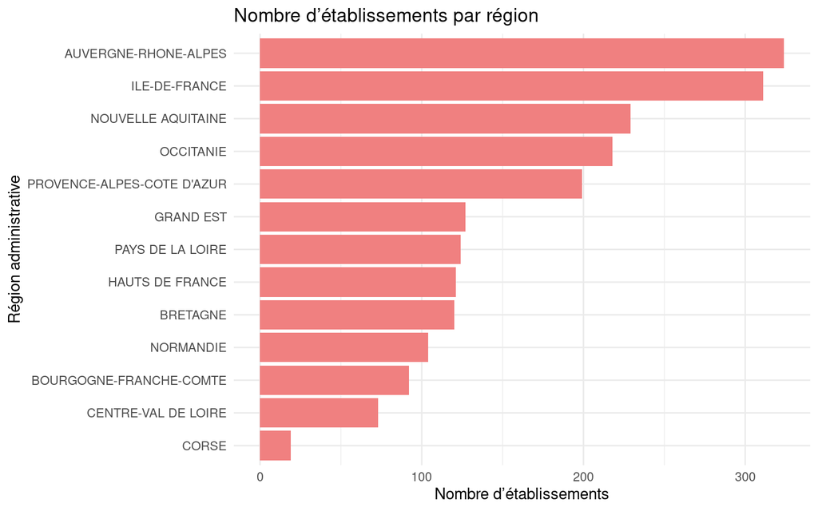

> **Observation :** L’Île-de-France concentre naturellement de nombreux établissements, mais certaines régions comme l’Auvergne-Rhône-Alpes ou PACA sont aussi bien représentées.

## 3.2 Distribution du nombre d’écrans par établissement

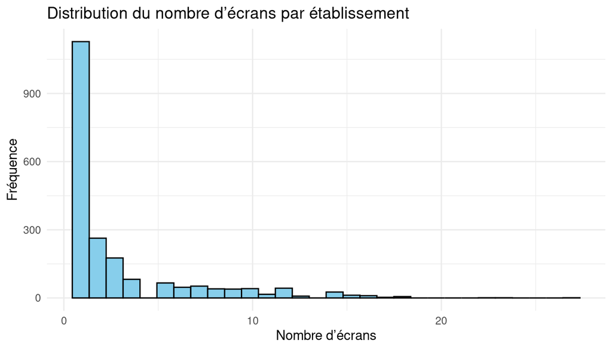

> **Observation :** La majorité des établissements possèdent moins de 5 écrans, les grands multiplexes restent minoritaires.

## 3.3 Entrées selon le type d’établissement (multiplexe)

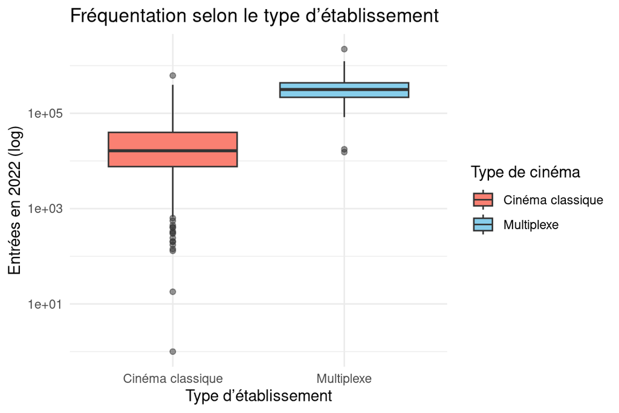

> **Observation :** Les multiplexes attirent en moyenne un volume de spectateurs bien plus important que les cinémas classiques, ce qui corrobore leur capacité logistique plus élevée (souvent supérieure à 7 écrans). Ce constat est d’ailleurs en cohérence avec la relation observée entre le nombre de fauteuils et la fréquentation globale, où l’on note qu’une plus grande capacité d’accueil entraîne une augmentation linéaire du nombre d’entrées.

## 3.4 Corrélation entre le nombre de fauteuils et les entrées

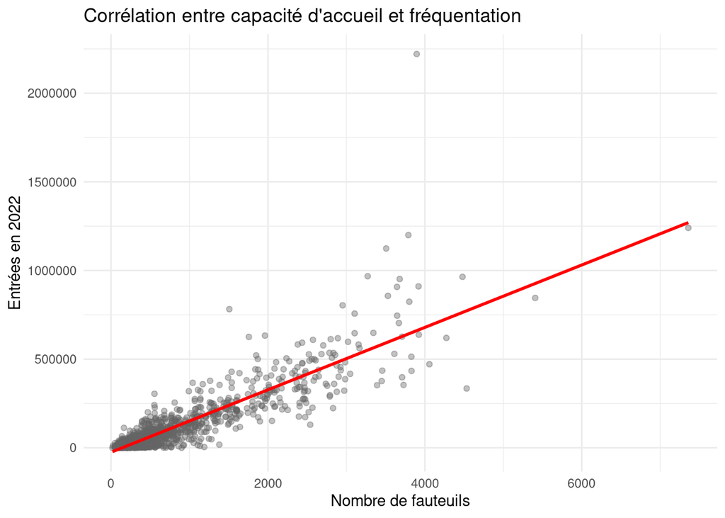

> **Observation :** Une relation linéaire est visible : plus un établissement dispose de places, plus le volume de spectateurs est élevé, bien que la corrélation ne soit pas parfaite.

## 3.5 Part de marché des films français

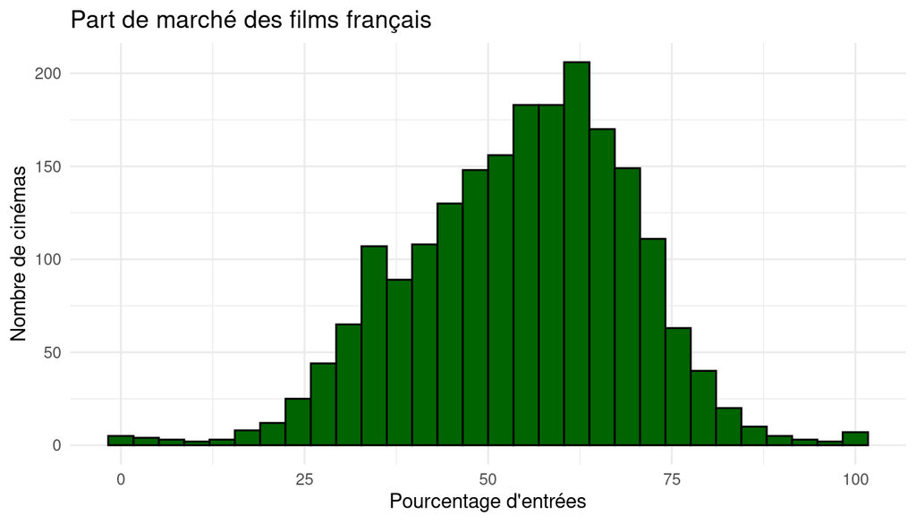

> **Observation :** Les films français conservent une part importante du marché dans de nombreux établissements, souvent supérieure à 40%.

## 3.6 Part moyenne de marché par type de film

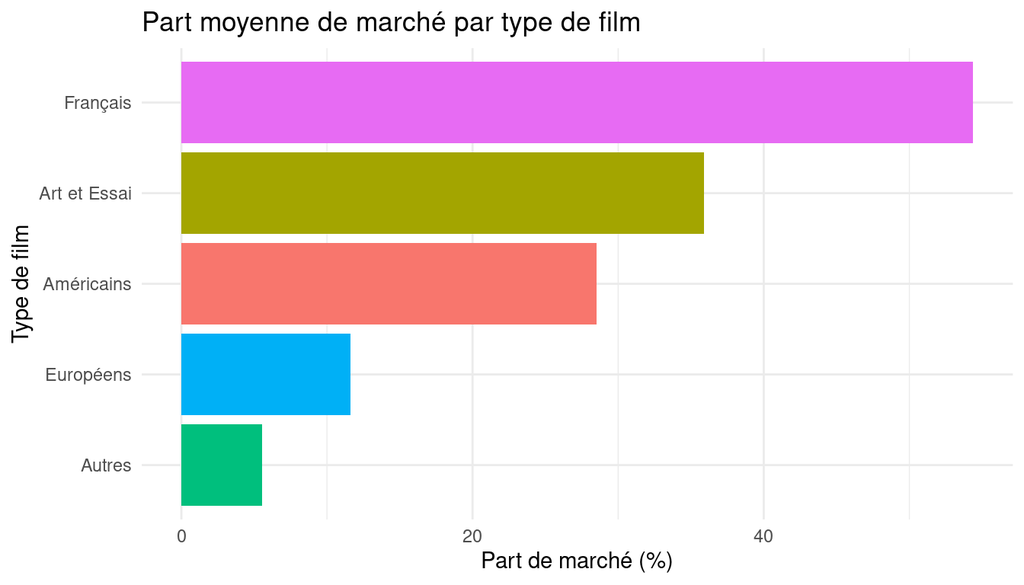

> **Observation :** Les films français représentent la plus grande part du marché en moyenne. Les films Art et Essai se démarquent par une présence significative, devançant même les films européens ou autres dans certains cas.

## 3.7 Distribution de la part des films Art et Essai

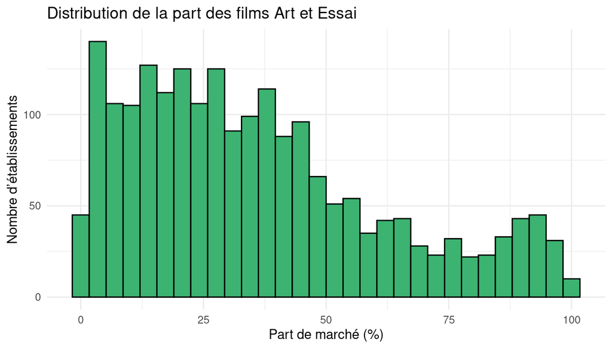

> La répartition globale des parts de marché des films Art et Essai fait apparaître une dispersion marquée, certains établissements atteignant des niveaux très élevés. Cela laisse supposer une segmentation territoriale ou structurelle. Le graphique suivant nous permet d’envisager cette hypothèse en examinant la distribution par zone géographique.

## 3.8 Comparaison : Art et Essai vs autres films

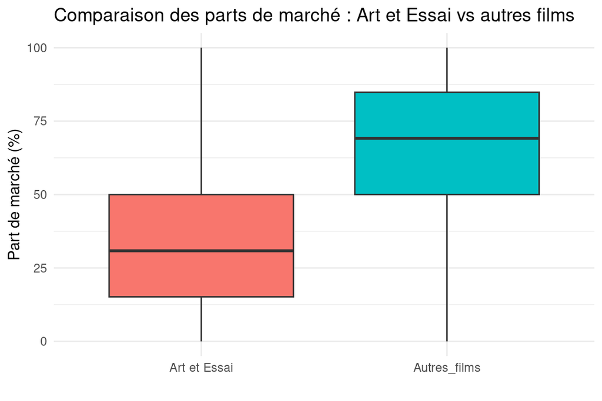

> **Observation :** Les films Art et Essai occupent une place notable dans de nombreux cinémas, mais restent généralement en deçà de la part cumulée des autres types de films.

## 3.9 Art et Essai selon zone géographique

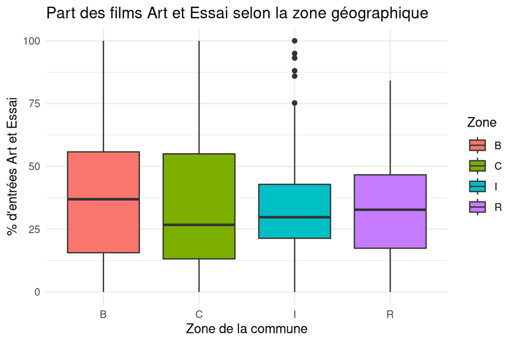

# 4 Conclusion

Cette étude descriptive permet de dresser un panorama des cinémas français :

- une répartition inégale mais active sur le territoire,
- une forte prédominance des petits établissements,
- des multiplexes qui concentrent une large part de la fréquentation,
- et une programmation qui valorise le cinéma national et le cinéma indépendant selon les zones.

> En reliant les capacités d’accueil, les types d’établissement et les parts de marché par catégorie de films, on observe une structuration cohérente du paysage cinématographique français. Les multiplexes urbains assurent les volumes, tandis que les établissements de plus petite taille, souvent situés hors métropoles, jouent un rôle clé dans la diversité culturelle, en valorisant notamment les films européens, Art et Essai, ou d’autres provenances.

Les questions posées ont trouvé des éléments de réponse grâce à des analyses visuelles claires et comparatives. Pour aller plus loin, des approches multivariées ou des comparaisons temporelles (avant/après-Covid) pourraient enrichir cette étude.

# 5 Annexe (optionnelle)

```r
# Exemple de fonction personnalisée
# get_top_regions <- function(df, var, top = 5) {
#   df %>% group_by(`région administrative`) %>%
#     summarise(val = sum({{ var }}, na.rm = TRUE)) %>%
#     top_n(top, val)
# }
```